# Homework 10

This solution uses the `RLT` package in R as required for Questions 1 and 2.

## Question 1: Bias-variance trade-off simulation

I used the fixed seed 43210 for the simulation study. The same 200 fixed test points were generated once and reused for all fits.

```r
library(RLT)
library(MASS)

set.seed(43210)
mu <- rep(0, 5)
Sigma <- matrix(0.3, 5, 5)
diag(Sigma) <- 1

x_test <- MASS::mvrnorm(200, mu, Sigma)
true_f <- x_test[, 1] + x_test[, 3] + x_test[, 5]

nmin_vals <- c(1, 5, 10, 20, 30)
mtry_vals <- c(1, 2, 3, 4, 5)
reps <- 100

training_data <- lapply(seq_len(reps), function(r) {
  x <- MASS::mvrnorm(200, mu, Sigma)
  y <- x[, 1] + x[, 3] + x[, 5] + rnorm(200)
  list(x = x, y = y)
})

summarise_settings <- function(parameter_vals, mode) {
  prediction_array <- array(
    NA_real_,
    dim = c(length(parameter_vals), reps, nrow(x_test))
  )
  for (r in seq_len(reps)) {
    x_train <- training_data[[r]]$x
    y_train <- training_data[[r]]$y
    for (i in seq_along(parameter_vals)) {
      fit <- RLT(
        x_train, y_train,
        model = "regression",
        ntrees = 500,
        mtry = if (mode == "mtry") parameter_vals[i] else 3,
        nmin = if (mode == "nmin") parameter_vals[i] else 10,
        resample.prob = 1,
        replacement = TRUE,
        importance = FALSE,
        print.summary = 0
      )
      prediction_array[i, r, ] <- predict(fit, x_test)$Prediction
    }
  }

  out <- data.frame(parameter = parameter_vals,
                    avg_bias2 = NA_real_,
                    avg_var = NA_real_)
  for (i in seq_along(parameter_vals)) {
    pred_mat <- prediction_array[i, , ]
    out$avg_bias2[i] <- mean((colMeans(pred_mat) - true_f)^2)
    out$avg_var[i] <- mean(apply(pred_mat, 2, var))
  }
  out
}

res_nmin <- summarise_settings(nmin_vals, "nmin")
res_mtry <- summarise_settings(mtry_vals, "mtry")
knitr::kable(res_nmin, digits = 4,
             caption = "Averaged squared bias and variance as node size varies with mtry = 3.")
```

Averaged squared bias and variance as node size varies with mtry = 3.

| parameter | avg_bias2 | avg_var |
| --- | --- | --- |
| 1 | 0.3270 | 0.1151 |
| 5 | 0.3312 | 0.1028 |
| 10 | 0.3692 | 0.0863 |
| 20 | 0.4868 | 0.0681 |
| 30 | 0.6178 | 0.0600 |

```r
knitr::kable(res_mtry, digits = 4,
             caption = "Averaged squared bias and variance as mtry varies with nmin = 10.")
```

Averaged squared bias and variance as mtry varies with nmin = 10.

| parameter | avg_bias2 | avg_var |
| --- | --- | --- |
| 1 | 0.9505 | 0.0444 |
| 2 | 0.4849 | 0.0663 |
| 3 | 0.3697 | 0.0853 |
| 4 | 0.3229 | 0.1028 |
| 5 | 0.2974 | 0.1174 |

### Figure 1: Varying node size while fixing `mtry = 3`

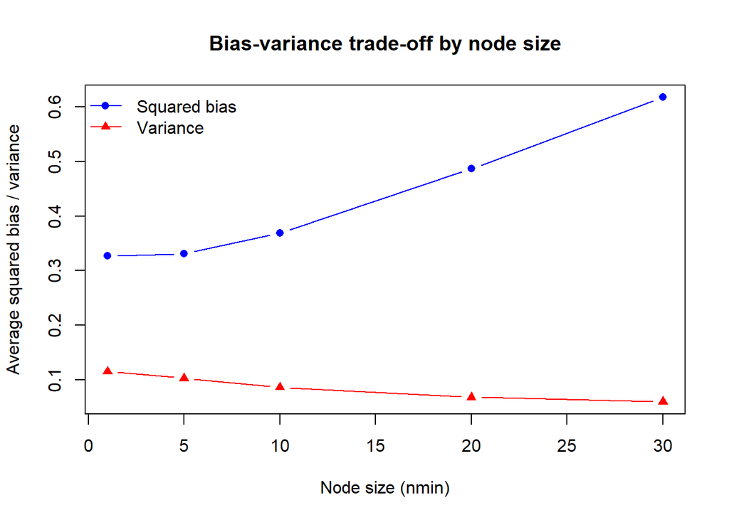

Averaged squared bias and variance across 100 repetitions as the node size varies; larger nmin increases bias and reduces variance.

### Figure 2: Varying `mtry` while fixing `nmin = 10`

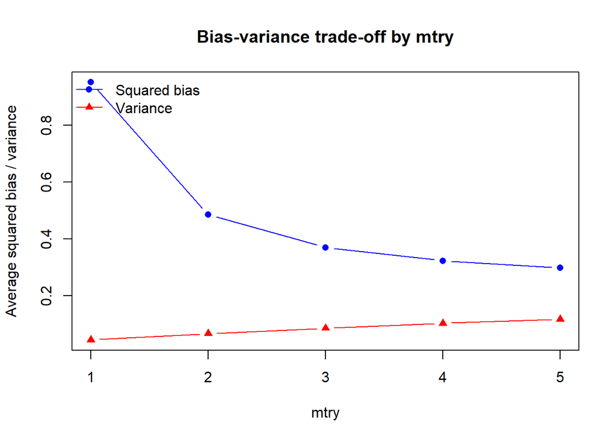

Averaged squared bias and variance across 100 repetitions as mtry varies; increasing mtry reduces bias but raises variance.

The simulation results are:

- For `mtry = 3` and varying `nmin`:
  - `nmin = 1`: bias = 0.3270, variance = 0.1151
  - `nmin = 5`: bias = 0.3312, variance = 0.1028
  - `nmin = 10`: bias = 0.3692, variance = 0.0863
  - `nmin = 20`: bias = 0.4868, variance = 0.0681
  - `nmin = 30`: bias = 0.6178, variance = 0.0600
- For `nmin = 10` and varying `mtry`:
  - `mtry = 1`: bias = 0.9505, variance = 0.0444
  - `mtry = 2`: bias = 0.4849, variance = 0.0663
  - `mtry = 3`: bias = 0.3697, variance = 0.0853
  - `mtry = 4`: bias = 0.3229, variance = 0.1028
  - `mtry = 5`: bias = 0.2974, variance = 0.1174

The `RLT` implementation imposes an internal minimum node size of two, so the requested `nmin = 1` setting is passed as requested but is fitted with its minimum supported node size.

These patterns match the bias-variance trade-off: larger node sizes produce less variable but more biased fits; larger `mtry` values reduce bias while increasing variance. The large-node-size case (`nmin = 30`) is too coarse and does not split deeply enough, so it underfits the signal. Using a large `mtry` is helpful when the signal is spread across multiple predictors because each split can consider more candidates, but it can also make the trees more similar, reducing the variance-reduction benefit of averaging. If each tree sampled only 100 observations instead of 200, I would expect the preferred node size to shift toward smaller values: with fewer distinct observations in each bootstrap sample, smaller leaves may be needed to represent the signal adequately. This is a reasoned expectation, not a guaranteed pattern.

## Question 2: Tuning random forests for MNIST

I used the criteria from the prompt exactly: digits 1, 6, and 7, PCA on the training data with 20 components, and classification forests with 1,000 trees. The training and test partitions are the first and second 1,000 rows, filtered to digits 1, 6, and 7.

```r
library(RLT)
set.seed(43211)

raw <- read.csv("data/mnist-first2000.csv.gz")
train_idx <- intersect(which(raw$Digit %in% c(1, 6, 7)),
                      which(seq_len(nrow(raw)) <= 1000))
test_idx <- intersect(which(raw$Digit %in% c(1, 6, 7)),
                     which(seq_len(nrow(raw)) > 1000))
train <- raw[train_idx, , drop = FALSE]
test <- raw[test_idx, , drop = FALSE]

X_train <- as.matrix(train[, grep("^Pixel", names(train))])
X_test <- as.matrix(test[, grep("^Pixel", names(test))])

pca_fit <- prcomp(X_train, center = TRUE, scale. = FALSE)
train_pc <- pca_fit$x[, 1:20]
test_pc <- predict(pca_fit, newdata = X_test)[, 1:20]

y_train <- factor(train$Digit)
y_test <- factor(test$Digit)

manual_oob_error <- function(X, y, mtry, nmin, bootstrap_samples) {
  ntrees <- length(bootstrap_samples)
  vote <- matrix(0, nrow(X), length(levels(y)))
  colnames(vote) <- levels(y)
  for (b in seq_len(ntrees)) {
    bag <- bootstrap_samples[[b]]
    fit_tmp <- RLT(
      X[bag, , drop = FALSE],
      y[bag],
      model = "classification",
      ntrees = 1,
      mtry = mtry,
      nmin = nmin,
      importance = FALSE,
      replacement = FALSE,
      resample.prob = 1,
      print.summary = 0
    )
    oob <- setdiff(seq_len(nrow(X)), unique(bag))
    if (length(oob) > 0) {
      prob <- predict(fit_tmp, X[oob, , drop = FALSE])$ProbPrediction
      if (is.null(dim(prob))) {
        prob <- matrix(prob, nrow = length(oob), ncol = length(levels(y)))
      }
      vote[oob, ] <- vote[oob, ] + prob
    }
  }
  if (any(rowSums(vote) == 0)) {
    stop("At least one training observation received no out-of-bag predictions.")
  }
  pred <- factor(levels(y)[max.col(vote)], levels = levels(y))
  mean(pred != y)
}

bootstrap_samples <- lapply(seq_len(1000), function(b) {
  sample.int(nrow(train_pc), size = nrow(train_pc), replace = TRUE)
})
mtry_vals <- c(2, 4, 6, 10)
nmin_vals <- c(1, 5, 10, 20)
grid <- expand.grid(mtry = mtry_vals, nmin = nmin_vals)
grid$oob <- vapply(seq_len(nrow(grid)), function(i) {
  manual_oob_error(train_pc, y_train, grid$mtry[i], grid$nmin[i],
                   bootstrap_samples)
}, numeric(1))

selected <- grid[order(grid$oob, grid$mtry, -grid$nmin)[1], , drop = FALSE]
default_mtry <- max(1, as.integer(ncol(train_pc) / 3))
default_nmin <- max(1, as.integer(log(nrow(train_pc))))
default_row <- which(grid$mtry == default_mtry & grid$nmin == default_nmin)
if (length(default_row) != 1) {
  stop("The tuning grid must contain exactly one default RLT setting.")
}
default_oob <- grid$oob[default_row]
selected_fit <- RLT(
  train_pc,
  y_train,
  model = "classification",
  ntrees = 1000,
  mtry = selected$mtry,
  nmin = selected$nmin,
  resample.prob = 1,
  replacement = TRUE,
  importance = TRUE,
  print.summary = 0
)

pred_test_int <- predict(selected_fit, test_pc)$Prediction
pred_test_lab <- levels(y_train)[pred_test_int + 1L]

cat(sprintf("Default RLT OOB error: %.5f\n", default_oob))
```

```
Default RLT OOB error: 0.03364
```

```r
cat(sprintf("Selected setting: mtry = %s, nmin = %s, OOB error = %.5f\n",
            selected$mtry, selected$nmin, selected$oob))
```

```
Selected setting: mtry = 2, nmin = 10, OOB error = 0.02141
```

```r
knitr::kable(grid, digits = 5,
             caption = "Grid search over mtry and node size using OOB misclassification rate.")
```

Grid search over mtry and node size using OOB misclassification rate.

| mtry | nmin | oob |
| --- | --- | --- |
| 2 | 1 | 0.02446 |
| 4 | 1 | 0.02752 |
| 6 | 1 | 0.03058 |
| 10 | 1 | 0.03364 |
| 2 | 5 | 0.02446 |
| 4 | 5 | 0.02141 |
| 6 | 5 | 0.03364 |
| 10 | 5 | 0.03364 |
| 2 | 10 | 0.02141 |
| 4 | 10 | 0.03058 |
| 6 | 10 | 0.03670 |
| 10 | 10 | 0.03364 |
| 2 | 20 | 0.03364 |
| 4 | 20 | 0.04281 |
| 6 | 20 | 0.03976 |
| 10 | 20 | 0.04281 |

```r
var_imp <- as.data.frame(t(selected_fit$VarImp))
var_imp$PC <- paste0("PC", 1:20)
var_imp <- var_imp[, c("PC", "V1")]
rownames(var_imp) <- NULL
names(var_imp) <- c("Principal component", "Importance")
knitr::kable(var_imp, digits = 4,
             caption = "OOB permutation variable importance for the 20 principal components in the selected forest.")
```

OOB permutation variable importance for the 20 principal components in the selected forest.

| Principal component | Importance |
| --- | --- |
| PC1 | 0.3227 |
| PC2 | 0.4282 |
| PC3 | 0.0828 |
| PC4 | 0.0518 |
| PC5 | 0.0837 |
| PC6 | 0.0795 |
| PC7 | 0.0588 |
| PC8 | 0.0377 |
| PC9 | 0.0303 |
| PC10 | 0.0403 |
| PC11 | 0.0563 |
| PC12 | 0.0471 |
| PC13 | 0.0370 |
| PC14 | 0.0405 |
| PC15 | 0.0265 |
| PC16 | 0.0368 |
| PC17 | 0.0321 |
| PC18 | 0.0436 |
| PC19 | 0.0260 |
| PC20 | 0.0307 |

```r
confusion <- table(pred_test_lab, y_test)
dimnames(confusion) <- list(Predicted = levels(y_train),
                            Actual = levels(y_test))
knitr::kable(confusion,
             caption = "Confusion matrix for the selected forest on the test set.")
```

Confusion matrix for the selected forest on the test set.

|  | 1 | 6 | 7 |
| --- | --- | --- | --- |
| 1 | 102 | 1 | 1 |
| 6 | 0 | 105 | 1 |
| 7 | 2 | 0 | 105 |

```r
cat(sprintf("Test misclassification rate: %.5f\n", mean(pred_test_lab != y_test)))
```

```
Test misclassification rate: 0.01577
```

### Results

The best OOB error is 0.02141, tied between two settings. I break the tie by choosing the smaller `mtry`, selecting `mtry = 2` and `nmin = 10`. The table reports the OOB error for every grid point.

RLT clamps node size to at least two, so the grid’s requested `nmin = 1` is fitted with `nmin = 2`. The selected forest’s OOB permutation importance is largest for PC2 and PC1, with PC3 and the remaining components much smaller. Permutation importance measures predictive contribution in this fitted forest; it does not establish that a component is intrinsically more meaningful.

The selected model misclassifies 5 of 317 held-out observations, for a test misclassification rate of 0.01577. The confusion matrix below is the final assessment only; test labels are not used in PCA fitting, tuning, or model selection.

The predicted class mapping and test-label comparison are performed only after the selected forest has been fixed. The test error and confusion matrix in the rendered report provide an independent assessment of the selected model.

## Question 3: Planning a random-forest analysis skill

A useful random-forest skill should not be a long generic list of everything a model can do; it should tell the AI which steps matter for the present problem, what choices are standard, and which choices are important to the analyst. I would start with a compact set of instructions about data checks, preprocessing, model specification, tuning, validation, and reporting. Then I would add a few personal preferences: use one shared validation scheme, keep figures small and interpretable, prefer simple models when performance is nearly tied, and briefly explain why the selected settings are plausible. The AI’s capability matters here. A stronger AI can probably infer conventional practice, so the skill should emphasize only the parts that reduce leakage or make the final analysis credible; a weaker AI benefits from more explicit reminders about folds, preprocessing, and the logic of model selection.

The 10 instructions I would include, from most basic to more personal, are:

1. Confirm the response type and whether the problem is regression or classification before fitting any forest.
2. Check the data structure, missing values, and class balance, and stop if the dataset is unsuitable.
3. Split the data into a fitting set and a final test set only once, with the test set reserved for the final assessment.
4. Use a reproducible random seed and keep the same validation scheme for all candidate models.
5. For preprocessing, center or scale predictors only inside the training folds, not before cross-validation.
6. Fit an ordinary random forest with the default `mtry` and node-size settings first as a baseline.
7. Tune the key parameters `mtry` and node size using a small grid and choose by out-of-bag or cross-validated error.
8. Prefer the simplest model within a narrow error band, rather than selecting a highly complex model with only a tiny gain.
9. Report a compact table of candidate settings, a small number of interpretable figures, and a clear description of the final model.
10. In the interpretation, highlight which variables or features matter most, explain the bias-variance trade-off, and justify the final model in plain language.

This is the right balance: a skill that standardizes good analysis practice while still leaving room for the analyst’s preferred reporting style and emphasis.